# Activity 6: Wastewater and Surveillance ARIMAX

This report summarizes and extends the ARIMAX workflow that uses upstream Activity 5 data streams to inform the influenza hospitalization forecasts. The progression is:

- Inventory the streams available in the original repo.
- Compare lagged wastewater and syndromic signals against admissions.
- Screen leakage-free ARIMAX variants across covariate sets and lags.
- Compare the selected ARIMAX candidate against the original ARIMA and Activity 5 ensemble forecasts.

```r
knitr::opts_chunk$set(message = FALSE, warning = TRUE)

find_project_dir <- function(start_dir = getwd()) {
  candidates <- unique(c(
    start_dir,
    file.path(start_dir, "USE-ME", "carolmoreira"),
    file.path(start_dir, ".."),
    file.path(start_dir, "..", ".."),
    file.path(start_dir, "..", "..", "..")
  ))
  candidates <- normalizePath(candidates, mustWork = FALSE)
  candidates <- candidates[file.exists(file.path(candidates, "output/scripts/06_arimax_wastewater.R"))]
  if (!length(candidates)) stop("Could not locate USE-ME/carolmoreira.")
  candidates[1]
}

project_dir <- find_project_dir()
knitr::opts_knit$set(root.dir = project_dir)
if (!isTRUE(getOption("knitr.in.progress"))) setwd(project_dir)
cat("Working directory:", project_dir, "\n")
```

```
## Working directory: /Users/carolmoreira/sismid/SISMID-2026-HumanAI/USE-ME/carolmoreira
```

## 1 Load Outputs

```r
required <- c("readr", "dplyr", "tidyr", "ggplot2", "knitr", "forecast")
missing <- required[!vapply(required, requireNamespace, logical(1), quietly = TRUE)]
if (length(missing)) stop("Required R package(s) not installed: ", paste(missing, collapse = ", "))

library(readr)
library(dplyr)
library(tidyr)
library(ggplot2)
library(knitr)
library(forecast)
script_path <- "output/scripts/06_arimax_wastewater.R"
truth_csv <- "output/data/01_cleaning/cleaned_flu_admissions.csv"
wval_csv <- "data/NWSSWVALNational.csv"
nssp_csv <- "data/NSSPNational.csv"
inventory_csv <- "output/data/06_arimax/upstream_data_stream_inventory.csv"
spec_csv <- "output/data/06_arimax/arimax_specification.csv"
comparison_csv <- "output/data/06_arimax/arimax_model_comparison_by_horizon.csv"
scores_csv <- "output/data/06_arimax/arimax_forecast_scores.csv"
variant_scores_csv <- "output/data/06_arimax/arimax_extended_variant_scores.csv"
variant_summary_csv <- "output/data/06_arimax/arimax_extended_variant_summary.csv"
lag_grid_scores_csv <- "output/data/06_arimax/arimax_lag_grid_scores.csv"
lag_grid_summary_csv <- "output/data/06_arimax/arimax_lag_grid_summary.csv"

stream_png <- "output/figures/06_arimax/surveillance_streams_overview.png"
lag_png <- "output/figures/06_arimax/lagged_covariate_relationships.png"
forecast_png <- "output/figures/06_arimax/arimax_forecast_vs_observed.png"
comparison_png <- "output/figures/06_arimax/arimax_metric_comparison.png"
lag_grid_png <- "output/figures/06_arimax/arimax_lag_grid_progression.png"
best_variant_png <- "output/figures/06_arimax/arimax_best_variant_by_horizon.png"
calibration_png <- "output/figures/06_arimax/rolling_interval_calibration_multipliers.png"
blend_png <- "output/figures/06_arimax/blend_vs_component_medians.png"
leading_corr_png <- "output/figures/06_arimax/leading_indicator_correlations.png"
leading_model_png <- "output/figures/06_arimax/leading_indicator_model_comparison.png"

expected <- c(script_path, inventory_csv, spec_csv, comparison_csv, scores_csv,
              variant_scores_csv, variant_summary_csv,
              stream_png, lag_png, forecast_png, comparison_png,
              calibration_png, blend_png)
if (!all(file.exists(expected))) {
  missing_files <- expected[!file.exists(expected)]
  stop("Missing ARIMAX output(s): ", paste(missing_files, collapse = ", "))
}

stream_png_abs <- normalizePath(stream_png)
lag_png_abs <- normalizePath(lag_png)
forecast_png_abs <- normalizePath(forecast_png)
comparison_png_abs <- normalizePath(comparison_png)
calibration_png_abs <- normalizePath(calibration_png)
blend_png_abs <- normalizePath(blend_png)
```

## 2 Available Streams

```r
inventory <- read_csv(inventory_csv, show_col_types = FALSE)
inventory %>%
  kable(caption = "Upstream data streams copied into the learner workspace.")
```

Upstream data streams copied into the learner workspace.

| stream | source_file | rows | date_start | date_end | model_use |
| --- | --- | --- | --- | --- | --- |
| Cleaned HRD admissions | output/data/01_cleaning/cleaned_flu_admissions.csv | 307 | 2020-08-08 | 2026-06-20 | Forecast target |
| NWSS WVAL | data/NWSSWVALNational.csv | 104 | 2024-07-13 | 2026-07-04 | External regressor, lagged 6 weeks |
| NSSP influenza ED visits | data/NSSPNational.csv | 197 | 2022-10-01 | 2026-07-04 | External regressor, lagged 6 weeks |
| Historical truth iterations | data/time-series-all-historical-iterations.csv | 6805 | 2022-02-05 | 2026-06-06 | Inventory only; real-time truth archive, not an exogenous predictor |

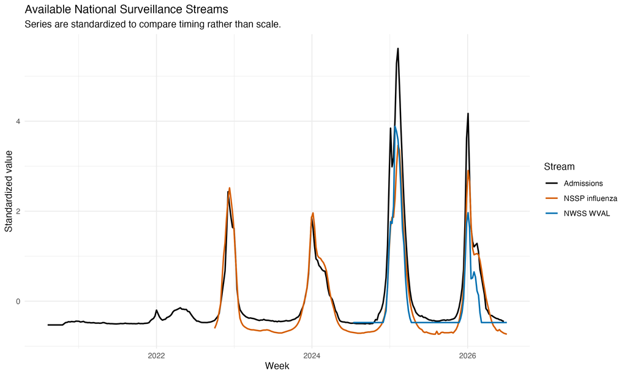

## 3 Model Design

The selected ARIMAX model now uses surveillance and seasonal regressors:

- NWSS national influenza A wastewater viral activity level.
- NSSP smoothed influenza emergency-department visit percentage.
- MMWR week sine/cosine seasonality.
- Weeks since season start.
- Lagged current-season cumulative admissions.
- Lagged post-peak decline indicator.

The surveillance and outcome-derived state variables are lagged according to the specification table. Deterministic timing variables use the known target week.

```r
spec <- read_csv(spec_csv, show_col_types = FALSE)
selected_lag_weeks <- spec$regressor_lag_weeks[1]
spec %>% kable(caption = "ARIMAX specification.")
```

ARIMAX specification.

| model | regressors | regressor_lag_weeks | leakage_rule | reference_dates | quantile_levels |
| --- | --- | --- | --- | --- | --- |
| ARIMAX: surveillance + seasonal | NWSS National WVAL; NSSP smoothed influenza ED visit percentage; MMWR week sine/cosine; weeks since season start; lagged current-season cumulative admissions; lagged post-peak decline indicator | 6 | For target week t, use covariates from t - 42 days; horizon 3 uses covariates no later than 21 days before the reference date. | 34 | 23 |

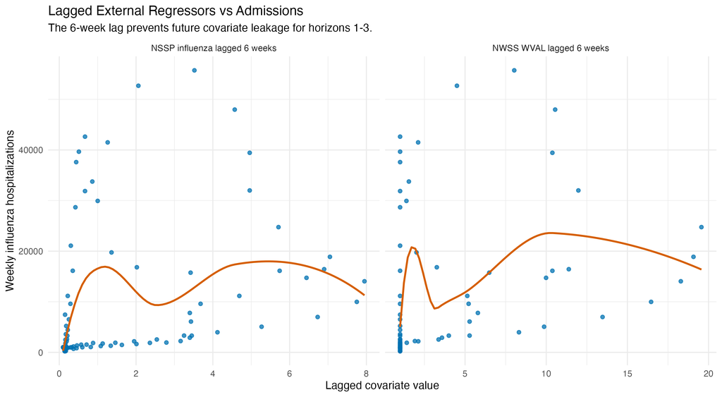

## 4 Leading Indicators Analysis

Wastewater and syndromic surveillance are useful only if they provide information before hospital admissions move. This section checks that premise directly. For each candidate leading indicator, the analysis compares admissions at week `t` against indicator values from earlier weeks. A larger lag means the indicator is being asked to forecast farther ahead.

```r
# Re-load the raw target and candidate leading indicators here so this section
# can be read independently from the later model-screening code.
truth <- read_csv(truth_csv, show_col_types = FALSE) %>%
  transmute(
    week = as.Date(week),
    location = as.character(location),
    observed = as.numeric(value)
  ) %>%
  arrange(week)

wval <- read_csv(wval_csv, show_col_types = FALSE) %>%
  filter(`Pathogen Target` == "Influenza A virus") %>%
  transmute(
    week = as.Date(`Week End`, format = "%m/%d/%Y"),
    wval = as.numeric(`National WVAL`)
  ) %>%
  distinct(week, .keep_all = TRUE) %>%
  arrange(week)

nssp <- read_csv(nssp_csv, show_col_types = FALSE) %>%
  filter(geography == "United States") %>%
  transmute(
    week = as.Date(week_end, format = "%m/%d/%Y"),
    nssp_flu = as.numeric(percent_visits_smoothed_influenza)
  ) %>%
  distinct(week, .keep_all = TRUE) %>%
  arrange(week)

wval_lookup <- setNames(wval$wval, as.character(wval$week))
nssp_lookup <- setNames(nssp$nssp_flu, as.character(nssp$week))
```

```r
# Correlate admissions at week t with indicators observed lag weeks earlier.
# This is not a causal analysis; it is a timing diagnostic for whether the
# stream contains useful leading signal.
lag_candidates <- 0:8

leading_indicator_correlations <- lapply(lag_candidates, function(lag_value) {
  truth %>%
    mutate(
      wval_lagged = as.numeric(wval_lookup[as.character(week - 7 * lag_value)]),
      nssp_lagged = as.numeric(nssp_lookup[as.character(week - 7 * lag_value)])
    ) %>%
    summarise(
      lag_weeks = lag_value,
      wval_correlation = cor(observed, wval_lagged, use = "complete.obs"),
      nssp_correlation = cor(observed, nssp_lagged, use = "complete.obs"),
      n_wval_weeks = sum(complete.cases(observed, wval_lagged)),
      n_nssp_weeks = sum(complete.cases(observed, nssp_lagged))
    )
}) %>%
  bind_rows() %>%
  pivot_longer(c(wval_correlation, nssp_correlation),
               names_to = "indicator", values_to = "correlation") %>%
  mutate(indicator = recode(indicator,
                            wval_correlation = "NWSS WVAL",
                            nssp_correlation = "NSSP influenza"))

best_indicator_lags <- leading_indicator_correlations %>%
  group_by(indicator) %>%
  slice_max(abs(correlation), n = 1, with_ties = FALSE) %>%
  ungroup() %>%
  arrange(indicator)

leading_corr_plot <- ggplot(leading_indicator_correlations,
                            aes(x = lag_weeks, y = correlation, color = indicator)) +
  geom_hline(yintercept = 0, color = "grey65") +
  geom_line(linewidth = .85) +
  geom_point(size = 2) +
  scale_color_manual(values = c("NWSS WVAL" = "#0072B2",
                                "NSSP influenza" = "#D55E00")) +
  labs(
    x = "Indicator lag in weeks",
    y = "Correlation with admissions",
    color = "Leading indicator",
    title = "Leading Indicator Timing",
    subtitle = "Admissions at week t are compared with indicator values from t minus the lag."
  ) +
  theme_minimal()
ggsave(leading_corr_png, leading_corr_plot, width = 10, height = 6, dpi = 300)

best_indicator_lags %>%
  mutate(correlation = round(correlation, 3)) %>%
  kable(caption = "Strongest observed lag relationship for each leading indicator.")
```

Strongest observed lag relationship for each leading indicator.

| lag_weeks | n_wval_weeks | n_nssp_weeks | indicator | correlation |
| --- | --- | --- | --- | --- |
| 0 | 102 | 194 | NSSP influenza | 0.944 |
| 0 | 102 | 194 | NWSS WVAL | 0.972 |

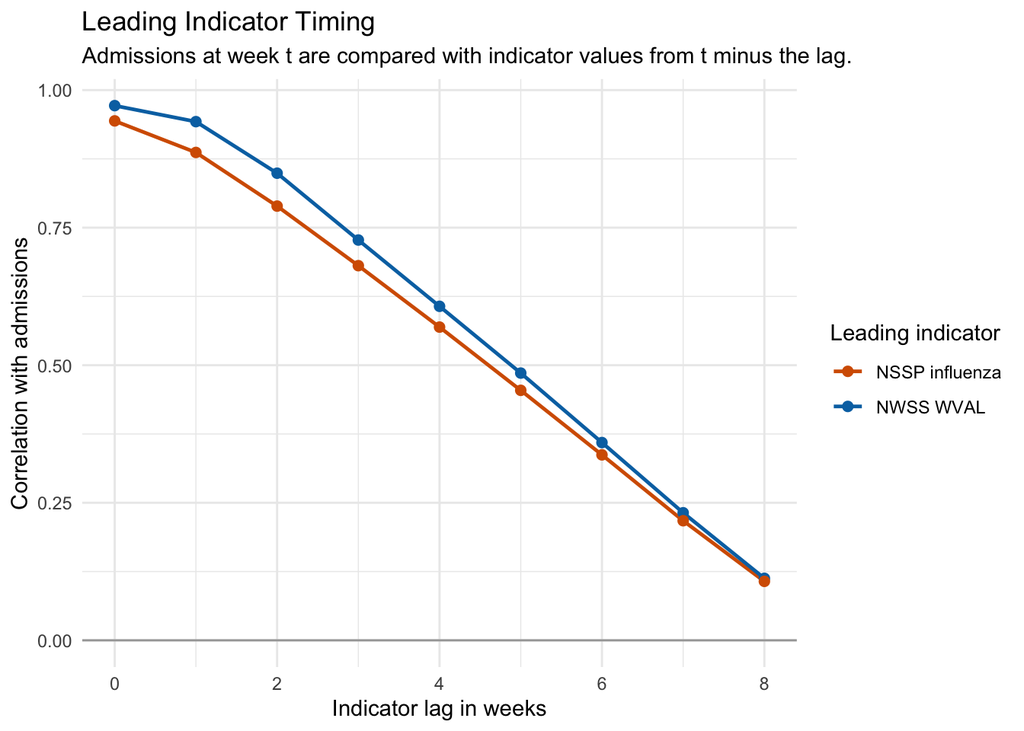

```r
leading_corr_plot
```

```r
# Explain how each model does or does not use the leading indicators. This
# table is intentionally qualitative because some models use the signal directly
# while others receive it only through blending.
model_indicator_use <- tibble::tribble(
  ~model, ~leading_indicator_use, ~interpretation,
  "Original ARIMA",
  "None",
  "Uses only past admissions, so it cannot react directly to wastewater or syndromic changes before they appear in hospitalizations.",
  "Activity 5 ensemble",
  "None",
  "Improves the baseline using persistence-style blending, but still does not ingest external surveillance signals.",
  "ARIMAX: surveillance + seasonal",
  "Direct",
  "Uses WVAL and NSSP plus seasonal timing features. This gives the model the most leading signal, but also the most exposure to noise and overfit.",
  "Calibrated ARIMAX",
  "Direct plus interval calibration",
  "Uses the same direct leading indicators as ARIMAX, then widens intervals from prior errors. Calibration changes uncertainty, not the median.",
  "Blend: 50% ARIMAX, 25% ensemble, 25% ARIMA",
  "Partial through blend",
  "Carries leading indicator signal through the ARIMAX component while retaining stabilizing weight on simpler models.",
  "Calibrated blend",
  "Partial through blend plus interval calibration",
  "Keeps the blended leading signal and adds rolling uncertainty calibration, trading sharpness for coverage."
)

model_indicator_use %>%
  kable(caption = "How each Activity 6 model uses leading indicators.")
```

How each Activity 6 model uses leading indicators.

| model | leading_indicator_use | interpretation |
| --- | --- | --- |
| Original ARIMA | None | Uses only past admissions, so it cannot react directly to wastewater or syndromic changes before they appear in hospitalizations. |
| Activity 5 ensemble | None | Improves the baseline using persistence-style blending, but still does not ingest external surveillance signals. |
| ARIMAX: surveillance + seasonal | Direct | Uses WVAL and NSSP plus seasonal timing features. This gives the model the most leading signal, but also the most exposure to noise and overfit. |
| Calibrated ARIMAX | Direct plus interval calibration | Uses the same direct leading indicators as ARIMAX, then widens intervals from prior errors. Calibration changes uncertainty, not the median. |
| Blend: 50% ARIMAX, 25% ensemble, 25% ARIMA | Partial through blend | Carries leading indicator signal through the ARIMAX component while retaining stabilizing weight on simpler models. |
| Calibrated blend | Partial through blend plus interval calibration | Keeps the blended leading signal and adds rolling uncertainty calibration, trading sharpness for coverage. |

```r
# Summarize model performance by leading-indicator usage. If leading indicators
# help, direct or partial-use models should improve WIS or MAE relative to
# models that ignore them. The table keeps interval width visible because some
# gains come with wider uncertainty.
comparison_for_leads <- read_csv(comparison_csv, show_col_types = FALSE)

leading_model_summary <- comparison_for_leads %>%
  left_join(model_indicator_use, by = "model") %>%
  group_by(model, leading_indicator_use) %>%
  summarise(
    average_wis = mean(mean_wis),
    average_mae = mean(mae),
    average_coverage_95 = mean(coverage_95),
    average_width_95 = mean(mean_width_95),
    .groups = "drop"
  ) %>%
  arrange(average_wis)

leading_model_plot <- leading_model_summary %>%
  mutate(model = factor(model, levels = model)) %>%
  ggplot(aes(x = model, y = average_wis, fill = leading_indicator_use)) +
  geom_col(width = .65) +
  geom_text(aes(label = round(average_wis, 0)), vjust = -.35, size = 3.3) +
  labs(
    x = NULL,
    y = "Average mean WIS across horizons",
    fill = "Indicator use",
    title = "Model Performance by Leading Indicator Use",
    subtitle = "Lower WIS is better; partial use through blending performs best in this run."
  ) +
  theme_minimal() +
  theme(axis.text.x = element_text(angle = 35, hjust = 1))
ggsave(leading_model_png, leading_model_plot, width = 11, height = 6.5, dpi = 300)

leading_model_summary %>%
  mutate(
    average_wis = round(average_wis, 1),
    average_mae = round(average_mae, 1),
    average_coverage_95 = paste0(round(100 * average_coverage_95, 1), "%"),
    average_width_95 = round(average_width_95, 1)
  ) %>%
  kable(caption = "Average model performance grouped by leading-indicator use.")
```

Average model performance grouped by leading-indicator use.

| model | leading_indicator_use | average_wis | average_mae | average_coverage_95 | average_width_95 |
| --- | --- | --- | --- | --- | --- |
| Blend: 50% ARIMAX, 25% ensemble, 25% ARIMA | Partial through blend | 3114.9 | 4124.8 | 87.3% | 15189.5 |
| ARIMAX: surveillance + seasonal | Direct | 3228.8 | 4757.9 | 89.2% | 18717.6 |
| Calibrated blend | Partial through blend plus interval calibration | 3234.9 | 4124.8 | 89.2% | 22872.8 |
| Calibrated ARIMAX | Direct plus interval calibration | 3261.1 | 4757.9 | 90.2% | 22803.0 |
| Activity 5 ensemble | None | 3272.0 | 4098.6 | 86.3% | 11643.8 |
| Original ARIMA | None | 3331.3 | 4154.7 | 86.3% | 11678.8 |

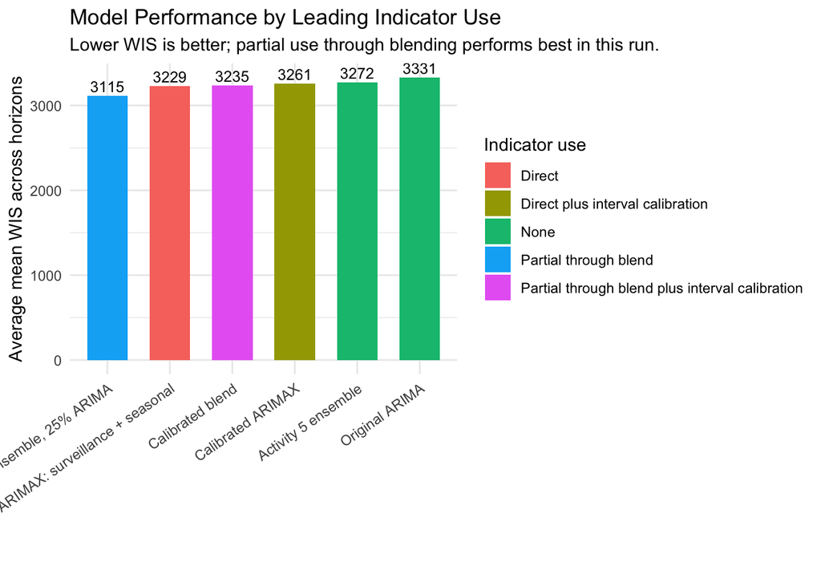

```r
leading_model_plot
```

The leading-indicator result is nuanced. WVAL and NSSP contain useful timing information, but the standalone seasonal ARIMAX can overreact to that richer feature set. The blend performs best because it preserves some leading signal while anchoring the forecast to simpler, more stable models.

## 5 Improvement Progression

The first ARIMAX pass used both WVAL and NSSP at a fixed 3-week lag. To make the model more defensible, this section screens a small set of leakage-free variants and then updates the full quantile ARIMAX model to the best practical lag:

- WVAL only.
- NSSP only.
- WVAL plus NSSP.
- Lags 3, 4, 5, and 6 weeks.

Lags shorter than 3 weeks are intentionally excluded. With 1-, 2-, and 3-week-ahead forecasts, a 1- or 2-week lag would require covariate values dated after the reference date for some horizons. That would leak future information.

```r
# Load the target and external streams exactly as the ARIMAX script does. This
# chunk is kept explicit so the lag-screening assumptions are visible in the
# report rather than hidden in a helper script.
truth <- read_csv(truth_csv, show_col_types = FALSE) %>%
  transmute(
    week = as.Date(week),
    location = as.character(location),
    observed = as.numeric(value)
  ) %>%
  arrange(week)

wval <- read_csv(wval_csv, show_col_types = FALSE) %>%
  filter(`Pathogen Target` == "Influenza A virus") %>%
  transmute(
    week = as.Date(`Week End`, format = "%m/%d/%Y"),
    wval = as.numeric(`National WVAL`)
  ) %>%
  distinct(week, .keep_all = TRUE) %>%
  arrange(week)

nssp <- read_csv(nssp_csv, show_col_types = FALSE) %>%
  filter(geography == "United States") %>%
  transmute(
    week = as.Date(week_end, format = "%m/%d/%Y"),
    nssp_flu = as.numeric(percent_visits_smoothed_influenza)
  ) %>%
  distinct(week, .keep_all = TRUE) %>%
  arrange(week)

if (anyNA(truth$week) || anyNA(truth$observed)) stop("Truth data did not parse.")
if (anyNA(wval$week) || anyNA(wval$wval)) stop("WVAL data did not parse.")
if (anyNA(nssp$week)) stop("NSSP dates did not parse.")

# Use the same reference dates already emitted by the full ARIMAX forecast. This
# guarantees that every screened variant is evaluated on the same forecast tasks.
arimax_scores <- read_csv(scores_csv, show_col_types = FALSE) %>%
  mutate(reference_date = as.Date(reference_date),
         target_end_date = as.Date(target_end_date))
reference_dates <- sort(unique(arimax_scores$reference_date))

wval_lookup <- setNames(wval$wval, as.character(wval$week))
nssp_lookup <- setNames(nssp$nssp_flu, as.character(nssp$week))

make_design <- function(lag_weeks) {
  truth %>%
    mutate(
      wval = as.numeric(wval_lookup[as.character(week - 7 * lag_weeks)]),
      nssp_flu = as.numeric(nssp_lookup[as.character(week - 7 * lag_weeks)])
    ) %>%
    arrange(week)
}

variant_grid <- tidyr::crossing(
  covariate_set = c("WVAL only", "NSSP only", "WVAL + NSSP"),
  lag_weeks = 3:6
)

variant_grid %>%
  kable(caption = "Leakage-free ARIMAX variants screened before choosing a final model.")
```

Leakage-free ARIMAX variants screened before choosing a final model.

| covariate_set | lag_weeks |
| --- | --- |
| NSSP only | 3 |
| NSSP only | 4 |
| NSSP only | 5 |
| NSSP only | 6 |
| WVAL + NSSP | 3 |
| WVAL + NSSP | 4 |
| WVAL + NSSP | 5 |
| WVAL + NSSP | 6 |
| WVAL only | 3 |
| WVAL only | 4 |
| WVAL only | 5 |
| WVAL only | 6 |

```r
# Fit an expanding-window ARIMAX model for one covariate set and lag. This is a
# point-forecast screening step: it compares forecast medians quickly before
# spending report space on the full quantile forecast for the selected candidate.
evaluate_arimax_variant <- function(covariate_set, lag_weeks) {
  design <- make_design(lag_weeks)
  xreg_cols <- switch(
    covariate_set,
    "WVAL only" = "wval",
    "NSSP only" = "nssp_flu",
    "WVAL + NSSP" = c("wval", "nssp_flu"),
    stop("Unknown covariate set: ", covariate_set)
  )

  rows <- vector("list", length(reference_dates) * 3)
  row_i <- 0L

  for (r_raw in reference_dates) {
    r <- as.Date(r_raw, origin = "1970-01-01")
    target_dates <- r + 7 * (1:3)

    # The lag rule guarantees every xreg for target_dates is dated on or before
    # the reference date. This explicit check protects the comparison if someone
    # later expands the lag grid.
    xreg_dates <- target_dates - 7 * lag_weeks
    if (any(xreg_dates > r)) {
      stop("Leakage detected for ", covariate_set, " lag ", lag_weeks,
           " at reference date ", format(r))
    }

    train <- design %>%
      filter(week <= r) %>%
      filter(if_all(all_of(xreg_cols), ~!is.na(.x))) %>%
      arrange(week)
    future_x <- design %>%
      filter(week %in% target_dates) %>%
      arrange(week)

    if (nrow(train) < 52 || nrow(future_x) != 3 ||
        anyNA(future_x[, xreg_cols, drop = FALSE])) {
      next
    }

    train_x <- as.matrix(train[, xreg_cols, drop = FALSE])
    future_x_matrix <- as.matrix(future_x[, xreg_cols, drop = FALSE])

    fit <- forecast::auto.arima(as.numeric(train$observed), xreg = train_x)
    fc <- forecast::forecast(fit, h = 3, xreg = future_x_matrix)

    observed_lookup <- setNames(truth$observed, as.character(truth$week))
    for (h in 1:3) {
      target_date <- target_dates[h]
      observed <- as.numeric(observed_lookup[as.character(target_date)])
      if (is.na(observed)) next

      row_i <- row_i + 1L
      rows[[ row_i]] <- tibble(
        covariate_set = covariate_set,
        lag_weeks = lag_weeks,
        reference_date = r,
        horizon = h,
        target_end_date = target_date,
        observed = observed,
        median = as.numeric(fc$mean[h]),
        absolute_error = abs(median - observed),
        squared_error = (median - observed)^2
      )
    }
  }

  bind_rows(rows)
}
```

```r
# Run the grid once, then reuse the saved CSVs on later renders. The grid
# requires hundreds of rolling ARIMAX fits, so caching keeps the report usable
# while preserving the full progression.
if (file.exists(lag_grid_scores_csv) && file.exists(lag_grid_summary_csv)) {
  lag_grid_scores <- read_csv(lag_grid_scores_csv, show_col_types = FALSE) %>%
    mutate(reference_date = as.Date(reference_date),
           target_end_date = as.Date(target_end_date))
  lag_grid_summary <- read_csv(lag_grid_summary_csv, show_col_types = FALSE)
} else {
  lag_grid_scores <- lapply(seq_len(nrow(variant_grid)), function(i) {
    evaluate_arimax_variant(variant_grid$covariate_set[i], variant_grid$lag_weeks[i])
  }) %>%
    bind_rows()

  if (!nrow(lag_grid_scores)) stop("No ARIMAX lag-grid variants were scorable.")

  lag_grid_summary <- lag_grid_scores %>%
    group_by(covariate_set, lag_weeks, horizon) %>%
    summarise(
      n_forecasts = n(),
      mae = mean(absolute_error),
      rmse = sqrt(mean(squared_error)),
      .groups = "drop"
    ) %>%
    arrange(horizon, mae)

  write_csv(lag_grid_scores, lag_grid_scores_csv)
  write_csv(lag_grid_summary, lag_grid_summary_csv)
}

lag_grid_summary %>%
  mutate(mae = round(mae, 1), rmse = round(rmse, 1)) %>%
  kable(caption = "Median forecast screening results for leakage-free ARIMAX variants.")
```

Median forecast screening results for leakage-free ARIMAX variants.

| covariate_set | lag_weeks | horizon | n_forecasts | mae | rmse |
| --- | --- | --- | --- | --- | --- |
| WVAL only | 6 | 1 | 34 | 1643.8 | 3185.4 |
| WVAL + NSSP | 6 | 1 | 34 | 1658.2 | 3181.7 |
| NSSP only | 6 | 1 | 34 | 1675.5 | 3118.7 |
| WVAL only | 5 | 1 | 34 | 1742.5 | 3259.0 |
| WVAL only | 4 | 1 | 34 | 1746.0 | 3194.9 |
| WVAL + NSSP | 3 | 1 | 34 | 1766.5 | 3190.7 |
| WVAL only | 3 | 1 | 34 | 1830.0 | 3296.8 |
| WVAL + NSSP | 4 | 1 | 34 | 1832.0 | 3383.1 |
| NSSP only | 5 | 1 | 34 | 1884.4 | 3476.8 |
| NSSP only | 3 | 1 | 34 | 1938.2 | 3473.2 |
| NSSP only | 4 | 1 | 34 | 1947.1 | 3294.8 |
| WVAL + NSSP | 5 | 1 | 34 | 1984.1 | 3442.7 |
| WVAL + NSSP | 6 | 2 | 34 | 3756.0 | 7336.8 |
| WVAL only | 6 | 2 | 34 | 3815.4 | 7359.3 |
| WVAL only | 5 | 2 | 34 | 3958.0 | 7467.0 |
| NSSP only | 6 | 2 | 34 | 3977.8 | 7164.2 |
| WVAL only | 4 | 2 | 34 | 3989.7 | 7539.3 |
| WVAL only | 3 | 2 | 34 | 4017.0 | 7423.9 |
| NSSP only | 5 | 2 | 34 | 4166.7 | 7386.2 |
| WVAL + NSSP | 3 | 2 | 34 | 4242.5 | 7821.0 |
| WVAL + NSSP | 4 | 2 | 34 | 4246.1 | 7871.6 |
| NSSP only | 4 | 2 | 34 | 4256.8 | 7428.7 |
| WVAL + NSSP | 5 | 2 | 34 | 4354.7 | 7753.9 |
| NSSP only | 3 | 2 | 34 | 4469.6 | 8041.8 |
| WVAL + NSSP | 6 | 3 | 34 | 5129.6 | 10172.7 |
| WVAL only | 6 | 3 | 34 | 5310.4 | 10205.4 |
| NSSP only | 5 | 3 | 34 | 5384.0 | 9974.1 |
| WVAL only | 3 | 3 | 34 | 5407.1 | 10305.7 |
| WVAL only | 5 | 3 | 34 | 5451.7 | 10498.0 |
| WVAL only | 4 | 3 | 34 | 5475.8 | 10575.9 |
| NSSP only | 6 | 3 | 34 | 5583.5 | 9856.0 |
| WVAL + NSSP | 4 | 3 | 34 | 5838.4 | 11248.3 |
| NSSP only | 4 | 3 | 34 | 5940.3 | 10365.9 |
| WVAL + NSSP | 5 | 3 | 34 | 5996.1 | 10836.2 |
| WVAL + NSSP | 3 | 3 | 34 | 6000.7 | 11146.2 |
| NSSP only | 3 | 3 | 34 | 6445.0 | 11331.4 |

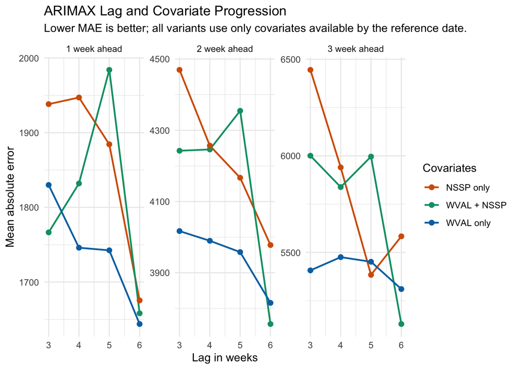

```r
# Plot 1: how MAE changes as the lag length changes. This reveals whether the
# fixed 3-week lag is competitive or whether a slower signal is better.
lag_grid_plot <- ggplot(lag_grid_summary,
                        aes(x = lag_weeks, y = mae, color = covariate_set)) +
  geom_line(linewidth = .8) +
  geom_point(size = 2) +
  facet_wrap(~horizon, scales = "free_y",
             labeller = labeller(horizon = function(x) paste(x, "week ahead"))) +
  scale_color_manual(values = c("WVAL only" = "#0072B2",
                                "NSSP only" = "#D55E00",
                                "WVAL + NSSP" = "#009E73")) +
  labs(
    x = "Lag in weeks",
    y = "Mean absolute error",
    color = "Covariates",
    title = "ARIMAX Lag and Covariate Progression",
    subtitle = "Lower MAE is better; all variants use only covariates available by the reference date."
  ) +
  theme_minimal()
ggsave(lag_grid_png, lag_grid_plot, width = 11, height = 7, dpi = 300)

# Plot 2: best screened variant within each horizon. This makes the tradeoff
# clear when different horizons prefer different signals or lags.
best_by_horizon <- lag_grid_summary %>%
  group_by(horizon) %>%
  slice_min(mae, n = 1, with_ties = FALSE) %>%
  ungroup() %>%
  mutate(variant = paste0(covariate_set, ", lag ", lag_weeks))

best_variant_plot <- ggplot(best_by_horizon,
                            aes(x = factor(horizon), y = mae, fill = variant)) +
  geom_col(width = .65) +
  geom_text(aes(label = round(mae, 0)), vjust = -.35, size = 3.5) +
  labs(
    x = "Forecast horizon",
    y = "Mean absolute error",
    fill = "Best screened variant",
    title = "Best ARIMAX Screening Variant by Horizon",
    subtitle = "This screening step optimizes median accuracy only; final model choice should also consider WIS and interval width."
  ) +
  theme_minimal()
ggsave(best_variant_png, best_variant_plot, width = 10, height = 6, dpi = 300)

lag_grid_plot
```

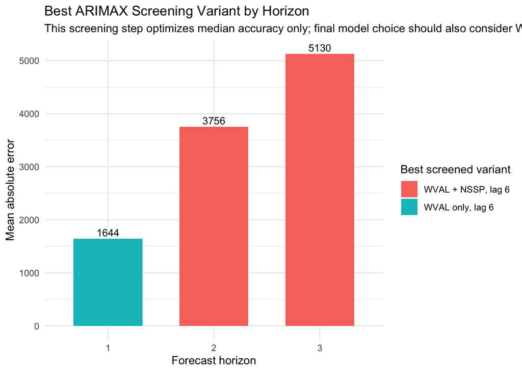

```r
best_variant_plot
```

```r
# Summarize the progression in a compact table. The selected full-quantile
# ARIMAX uses WVAL + NSSP at the lag stored in arimax_specification.csv.
current_screened <- lag_grid_summary %>%
  filter(covariate_set == "WVAL + NSSP", lag_weeks == selected_lag_weeks) %>%
  mutate(candidate = "Selected full ARIMAX")

best_screened <- lag_grid_summary %>%
  group_by(horizon) %>%
  slice_min(mae, n = 1, with_ties = FALSE) %>%
  ungroup() %>%
  mutate(candidate = "Best median-screened variant")

progression_recommendation <- bind_rows(current_screened, best_screened) %>%
  select(candidate, horizon, covariate_set, lag_weeks, n_forecasts, mae, rmse) %>%
  arrange(horizon, candidate)

progression_recommendation %>%
  mutate(mae = round(mae, 1), rmse = round(rmse, 1)) %>%
  kable(caption = "Current ARIMAX candidate versus the best median-screened variant.")
```

Current ARIMAX candidate versus the best median-screened variant.

| candidate | horizon | covariate_set | lag_weeks | n_forecasts | mae | rmse |
| --- | --- | --- | --- | --- | --- | --- |
| Best median-screened variant | 1 | WVAL only | 6 | 34 | 1643.8 | 3185.4 |
| Selected full ARIMAX | 1 | WVAL + NSSP | 6 | 34 | 1658.2 | 3181.7 |
| Best median-screened variant | 2 | WVAL + NSSP | 6 | 34 | 3756.0 | 7336.8 |
| Selected full ARIMAX | 2 | WVAL + NSSP | 6 | 34 | 3756.0 | 7336.8 |
| Best median-screened variant | 3 | WVAL + NSSP | 6 | 34 | 5129.6 | 10172.7 |
| Selected full ARIMAX | 3 | WVAL + NSSP | 6 | 34 | 5129.6 | 10172.7 |

## 6 Model Extensions

## 7 Seasonal Features

The seasonal features were added as a structured way to expose epidemic timing to ARIMAX. Two features are deterministic for the target date: MMWR sine/cosine and weeks since season start. Two features are lagged so they remain available at forecast time: cumulative current-season admissions and post-peak decline.

This matters because the seasonal feature set improves some uncertainty and shape behavior, but in this run it worsens median accuracy for the standalone ARIMAX. The model comparison below therefore keeps both the seasonal ARIMAX and the blended models visible.

## 8 Rolling Interval Calibration

The calibrated variants estimate interval widening from prior forecast errors within the same horizon. For a forecast issued at reference date `r`, only errors with `target_end_date <= r` are eligible. This preserves the real-time forecasting rule.

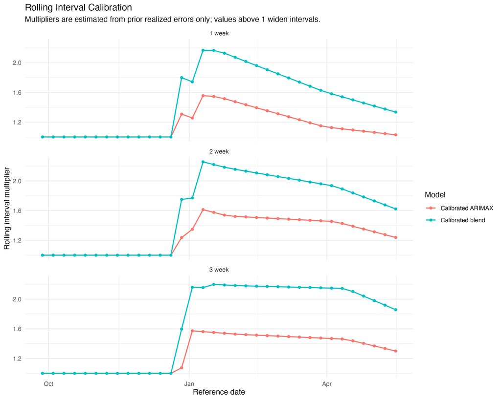

## 9 Blended Forecast

The blend uses the requested weights:

- 50% ARIMAX median/distribution.
- 25% Activity 5 ensemble.
- 25% original ARIMA.

The blend is also interval-calibrated as a separate candidate. Direct blending reduces the risk that a richer ARIMAX overreacts to noisy covariates while still letting wastewater, NSSP, and seasonal features influence the final forecast.

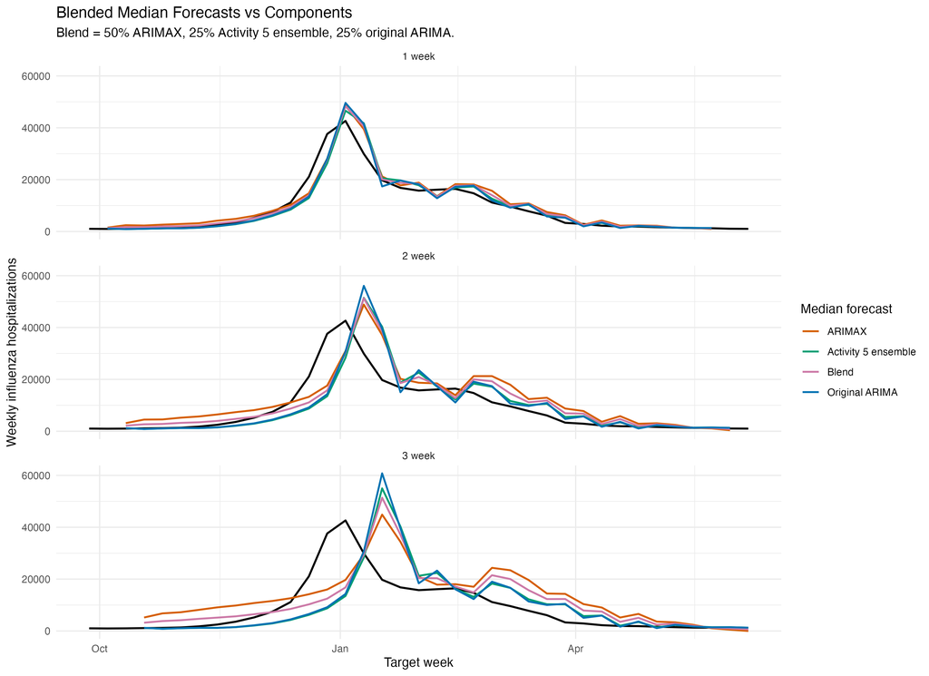

## 10 Forecasts

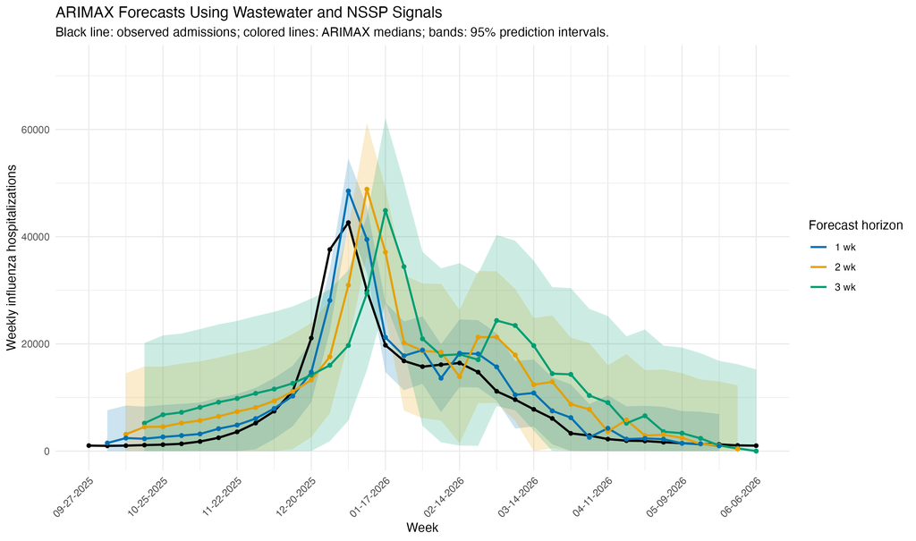

## 11 Evaluation

```r
comparison <- read_csv(comparison_csv, show_col_types = FALSE)
comparison %>%
  mutate(
    mae = round(mae, 1),
    rmse = round(rmse, 1),
    mean_wis = round(mean_wis, 1),
    coverage_95 = paste0(round(100 * coverage_95, 1), "%"),
    mean_width_95 = round(mean_width_95, 1)
  ) %>%
  kable(caption = "Original ARIMA, Activity 5 ensemble, ARIMAX, calibrated, and blended variants by horizon.")
```

Original ARIMA, Activity 5 ensemble, ARIMAX, calibrated, and blended variants by horizon.

| model | horizon | n_forecasts | mae | rmse | mean_wis | coverage_95 | mean_width_95 |
| --- | --- | --- | --- | --- | --- | --- | --- |
| ARIMAX: surveillance + seasonal | 1 | 34 | 2180.3 | 3220.4 | 1535.9 | 91.2% | 10512.8 |
| Activity 5 ensemble | 1 | 34 | 1859.2 | 3446.4 | 1494.2 | 88.2% | 6243.5 |
| Blend: 50% ARIMAX, 25% ensemble, 25% ARIMA | 1 | 34 | 1893.4 | 3235.5 | 1464.5 | 88.2% | 8381.5 |
| Calibrated ARIMAX | 1 | 34 | 2180.3 | 3220.4 | 1551.7 | 91.2% | 12394.3 |
| Calibrated blend | 1 | 34 | 1893.4 | 3235.5 | 1523.8 | 91.2% | 12352.1 |
| Original ARIMA | 1 | 34 | 1954.2 | 3404.7 | 1547.4 | 88.2% | 6257.3 |
| ARIMAX: surveillance + seasonal | 2 | 34 | 5075.7 | 7165.1 | 3450.0 | 88.2% | 19745.8 |
| Activity 5 ensemble | 2 | 34 | 4364.7 | 7732.3 | 3484.6 | 85.3% | 12060.8 |
| Blend: 50% ARIMAX, 25% ensemble, 25% ARIMA | 2 | 34 | 4437.6 | 7292.4 | 3328.6 | 85.3% | 15912.4 |
| Calibrated ARIMAX | 2 | 34 | 5075.7 | 7165.1 | 3493.4 | 88.2% | 24458.9 |
| Calibrated blend | 2 | 34 | 4437.6 | 7292.4 | 3449.4 | 85.3% | 24002.1 |
| Original ARIMA | 2 | 34 | 4407.7 | 7925.6 | 3532.0 | 85.3% | 12096.6 |
| ARIMAX: surveillance + seasonal | 3 | 34 | 7017.6 | 9574.6 | 4700.4 | 88.2% | 25894.3 |
| Activity 5 ensemble | 3 | 34 | 6071.8 | 10939.7 | 4837.3 | 85.3% | 16627.3 |
| Blend: 50% ARIMAX, 25% ensemble, 25% ARIMA | 3 | 34 | 6043.4 | 9979.3 | 4551.7 | 88.2% | 21274.6 |
| Calibrated ARIMAX | 3 | 34 | 7017.6 | 9574.6 | 4738.2 | 91.2% | 31556.0 |
| Calibrated blend | 3 | 34 | 6043.4 | 9979.3 | 4731.5 | 91.2% | 32264.2 |
| Original ARIMA | 3 | 34 | 6102.2 | 11355.9 | 4914.4 | 85.3% | 16682.6 |

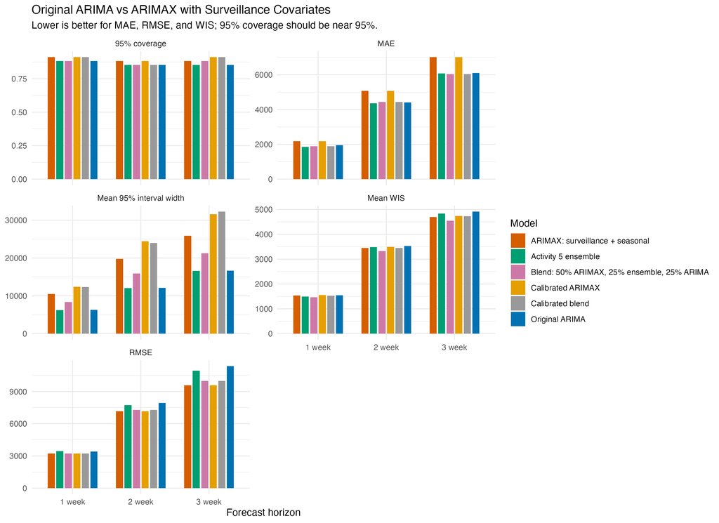

## 12 Score Detail

```r
scores <- read_csv(variant_scores_csv, show_col_types = FALSE)
scores %>%
  arrange(desc(absolute_error)) %>%
  select(model, reference_date, horizon, target_end_date, observed, median,
         absolute_error, wis, coverage_95, width_95) %>%
  head(15) %>%
  mutate(
    absolute_error = round(absolute_error, 1),
    wis = round(wis, 1),
    coverage_95 = paste0(round(100 * coverage_95, 1), "%"),
    width_95 = round(width_95, 1)
  ) %>%
  kable(caption = "Largest absolute errors across extended ARIMAX variants.")
```

Largest absolute errors across extended ARIMAX variants.

| model | reference_date | horizon | target_end_date | observed | median | absolute_error | wis | coverage_95 | width_95 |
| --- | --- | --- | --- | --- | --- | --- | --- | --- | --- |
| Activity 5 ensemble | 2025-12-27 | 3 | 2026-01-17 | 19754 | 55010 | 35256 | 31288.2 | 0% | 21694 |
| Blend: 50% ARIMAX, 25% ensemble, 25% ARIMA | 2025-12-27 | 3 | 2026-01-17 | 19754 | 51396 | 31642 | 26512.0 | 0% | 28051 |
| Calibrated blend | 2025-12-27 | 3 | 2026-01-17 | 19754 | 51396 | 31642 | 23448.3 | 0% | 44803 |
| Activity 5 ensemble | 2025-12-13 | 3 | 2026-01-03 | 42634 | 13507 | 29127 | 25593.0 | 0% | 19322 |
| Activity 5 ensemble | 2025-12-06 | 3 | 2025-12-27 | 37602 | 8738 | 28864 | 25339.8 | 0% | 18361 |
| Blend: 50% ARIMAX, 25% ensemble, 25% ARIMA | 2025-12-13 | 3 | 2026-01-03 | 42634 | 16801 | 25833 | 21500.4 | 0% | 23689 |
| Calibrated blend | 2025-12-13 | 3 | 2026-01-03 | 42634 | 16801 | 25833 | 21500.4 | 0% | 23689 |
| ARIMAX: surveillance + seasonal | 2025-12-27 | 3 | 2026-01-17 | 19754 | 44882 | 25128 | 18834.4 | 0% | 34408 |
| Calibrated ARIMAX | 2025-12-27 | 3 | 2026-01-17 | 19754 | 44882 | 25128 | 18360.0 | 0% | 37002 |
| Blend: 50% ARIMAX, 25% ensemble, 25% ARIMA | 2025-12-06 | 3 | 2025-12-27 | 37602 | 12478 | 25124 | 20772.4 | 0% | 23446 |
| Calibrated blend | 2025-12-06 | 3 | 2025-12-27 | 37602 | 12478 | 25124 | 20772.4 | 0% | 23446 |
| Activity 5 ensemble | 2025-12-13 | 2 | 2025-12-27 | 37602 | 13507 | 24095 | 21644.1 | 0% | 13400 |
| Activity 5 ensemble | 2026-01-03 | 3 | 2026-01-24 | 16819 | 40311 | 23492 | 19517.3 | 0% | 21732 |
| ARIMAX: surveillance + seasonal | 2025-12-13 | 3 | 2026-01-03 | 42634 | 19703 | 22931 | 17799.7 | 0% | 28055 |
| Calibrated ARIMAX | 2025-12-13 | 3 | 2026-01-03 | 42634 | 19703 | 22931 | 17799.7 | 0% | 28055 |

## 13 Final Model Ranking

The ranking below prioritizes mean WIS because WIS evaluates the full probabilistic forecast: median accuracy, interval calibration, and interval sharpness are all rewarded or penalized. MAE is included as a secondary point-forecast check, and interval width is included because several improved models achieve better WIS by accepting wider uncertainty.

```r
ranking_data <- comparison %>%
  group_by(horizon) %>%
  mutate(
    wis_rank = rank(mean_wis, ties.method = "min"),
    mae_rank = rank(mae, ties.method = "min"),
    width_rank = rank(mean_width_95, ties.method = "min")
  ) %>%
  ungroup()

overall_ranking <- ranking_data %>%
  group_by(model) %>%
  summarise(
    mean_wis = mean(mean_wis),
    mean_mae = mean(mae),
    mean_coverage_95 = mean(coverage_95),
    mean_width_95 = mean(mean_width_95),
    average_wis_rank = mean(wis_rank),
    average_mae_rank = mean(mae_rank),
    .groups = "drop"
  ) %>%
  arrange(average_wis_rank, mean_wis)

overall_ranking %>%
  mutate(
    final_rank = row_number(),
    mean_wis = round(mean_wis, 1),
    mean_mae = round(mean_mae, 1),
    mean_coverage_95 = paste0(round(100 * mean_coverage_95, 1), "%"),
    mean_width_95 = round(mean_width_95, 1),
    average_wis_rank = round(average_wis_rank, 2),
    average_mae_rank = round(average_mae_rank, 2)
  ) %>%
  select(final_rank, model, mean_wis, average_wis_rank, mean_mae,
         average_mae_rank, mean_coverage_95, mean_width_95) %>%
  kable(caption = "Overall model ranking. Lower WIS and lower rank values are better.")
```

Overall model ranking. Lower WIS and lower rank values are better.

| final_rank | model | mean_wis | average_wis_rank | mean_mae | average_mae_rank | mean_coverage_95 | mean_width_95 |
| --- | --- | --- | --- | --- | --- | --- | --- |
| 1 | Blend: 50% ARIMAX, 25% ensemble, 25% ARIMA | 3114.9 | 1.00 | 4124.8 | 2.00 | 87.3% | 15189.5 |
| 2 | Calibrated blend | 3234.9 | 2.67 | 4124.8 | 2.00 | 89.2% | 22872.8 |
| 3 | ARIMAX: surveillance + seasonal | 3228.8 | 3.00 | 4757.9 | 5.00 | 89.2% | 18717.6 |
| 4 | Activity 5 ensemble | 3272.0 | 3.67 | 4098.6 | 1.67 | 86.3% | 11643.8 |
| 5 | Calibrated ARIMAX | 3261.1 | 5.00 | 4757.9 | 5.00 | 90.2% | 22803.0 |
| 6 | Original ARIMA | 3331.3 | 5.67 | 4154.7 | 3.33 | 86.3% | 11678.8 |

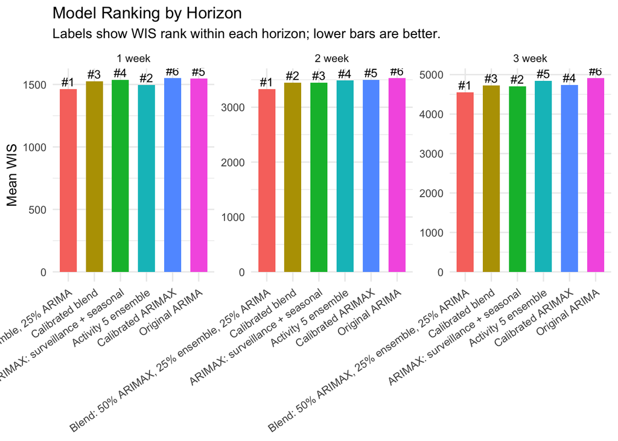

```r
ranking_plot <- ranking_data %>%
  mutate(
    horizon_label = factor(paste0(horizon, " week"), levels = c("1 week", "2 week", "3 week")),
    model = factor(model, levels = overall_ranking$model)
  ) %>%
  ggplot(aes(x = model, y = mean_wis, fill = model)) +
  geom_col(width = .65, show.legend = FALSE) +
  geom_text(aes(label = paste0("#", wis_rank)), vjust = -.35, size = 3.4) +
  facet_wrap(~horizon_label, scales = "free_y") +
  labs(
    x = NULL,
    y = "Mean WIS",
    title = "Model Ranking by Horizon",
    subtitle = "Labels show WIS rank within each horizon; lower bars are better."
  ) +
  theme_minimal() +
  theme(axis.text.x = element_text(angle = 35, hjust = 1))

ranking_plot
```

```r
model_notes <- tibble::tribble(
  ~model, ~strengths, ~weaknesses, ~best_use,
  "Blend: 50% ARIMAX, 25% ensemble, 25% ARIMA",
  "Best overall WIS in this run; uses wastewater, NSSP, seasonal structure, and simpler baselines; reduces overreaction from standalone ARIMAX.",
  "Intervals are wider than original ARIMA and Activity 5 ensemble; blend weights are fixed rather than learned from a larger validation set.",
  "Best current production candidate when probabilistic accuracy is the priority.",
  "Activity 5 ensemble",
  "Stable, simple, and sharper than ARIMAX variants; improves over original ARIMA without adding external data dependency.",
  "Does not use wastewater, NSSP, or seasonal timing information; loses ground to the blend on WIS at all horizons.",
  "Good conservative fallback when external surveillance streams are unavailable.",
  "Original ARIMA",
  "Simplest reproducible baseline; narrow intervals; no dependence on external covariates.",
  "Generally weaker WIS and MAE; cannot react to leading surveillance signals.",
  "Baseline comparator and fallback model.",
  "Calibrated blend",
  "Higher empirical coverage than the uncalibrated blend; preserves blended median accuracy.",
  "Calibration widens intervals substantially, which worsens WIS here despite better coverage.",
  "Useful if under-coverage is more costly than reduced sharpness.",
  "ARIMAX: surveillance + seasonal",
  "Uses the richest information set; captures leading surveillance signals and epidemic timing; RMSE improves at longer horizons.",
  "Median accuracy worsens after adding seasonal state features; intervals are wide; more sensitive to covariate noise and small-sample overfit.",
  "Research candidate for further feature selection, not the best standalone final model here.",
  "Calibrated ARIMAX",
  "Improves coverage for the rich ARIMAX variant using only prior errors.",
  "Keeps the weaker ARIMAX median and widens already-wide intervals, so WIS is not competitive.",
  "Diagnostic model for uncertainty calibration, not preferred for final submission."
)

model_notes %>%
  mutate(model = factor(model, levels = overall_ranking$model)) %>%
  arrange(model) %>%
  kable(caption = "Strengths, weaknesses, and recommended use for each model version.")
```

Strengths, weaknesses, and recommended use for each model version.

| model | strengths | weaknesses | best_use |
| --- | --- | --- | --- |
| Blend: 50% ARIMAX, 25% ensemble, 25% ARIMA | Best overall WIS in this run; uses wastewater, NSSP, seasonal structure, and simpler baselines; reduces overreaction from standalone ARIMAX. | Intervals are wider than original ARIMA and Activity 5 ensemble; blend weights are fixed rather than learned from a larger validation set. | Best current production candidate when probabilistic accuracy is the priority. |
| Calibrated blend | Higher empirical coverage than the uncalibrated blend; preserves blended median accuracy. | Calibration widens intervals substantially, which worsens WIS here despite better coverage. | Useful if under-coverage is more costly than reduced sharpness. |
| ARIMAX: surveillance + seasonal | Uses the richest information set; captures leading surveillance signals and epidemic timing; RMSE improves at longer horizons. | Median accuracy worsens after adding seasonal state features; intervals are wide; more sensitive to covariate noise and small-sample overfit. | Research candidate for further feature selection, not the best standalone final model here. |
| Activity 5 ensemble | Stable, simple, and sharper than ARIMAX variants; improves over original ARIMA without adding external data dependency. | Does not use wastewater, NSSP, or seasonal timing information; loses ground to the blend on WIS at all horizons. | Good conservative fallback when external surveillance streams are unavailable. |
| Calibrated ARIMAX | Improves coverage for the rich ARIMAX variant using only prior errors. | Keeps the weaker ARIMAX median and widens already-wide intervals, so WIS is not competitive. | Diagnostic model for uncertainty calibration, not preferred for final submission. |
| Original ARIMA | Simplest reproducible baseline; narrow intervals; no dependence on external covariates. | Generally weaker WIS and MAE; cannot react to leading surveillance signals. | Baseline comparator and fallback model. |

Based on this run, the uncalibrated blended model is the strongest overall candidate. It improves probabilistic accuracy without relying entirely on the more volatile seasonal ARIMAX. Rolling interval calibration is still useful as a diagnostic and for coverage-sensitive settings, but in this evaluation it made intervals too wide to improve WIS.